# step_one::introduction

*Visualizing Loans Awarded by Kiva*

In this project you'll visualize insights using a dataset from Kaggle. The dataset contains information about loans awarded by the non-profit Kiva.

Using Seaborn, you'll explore the average loan amount by country using aggregated bar charts. You'll also visualize the distribution of loan amounts by project type and gender using box plots and violin plots

# step_two::Import Necessary Python Modules

```python
import pandas as pd
import matplotlib.pyplot as plt
import seaborn as sns
%matplotlib inline
```

# Step_three:: Ingest The Data

```python
df=pd.read_csv('C:/Users/amr/Downloads/code_academy _course/seabornProjectCumulative/kiva_data.csv')
df.head(7)
```

|  | loan_amount | activity | country | gender |
| --- | --- | --- | --- | --- |
| 0 | 625 | Food Production/Sales | Pakistan | female |
| 1 | 250 | Food Production/Sales | Pakistan | female |
| 2 | 400 | Food Production/Sales | Pakistan | female |
| 3 | 400 | Food Production/Sales | Pakistan | female |
| 4 | 500 | Food Production/Sales | Pakistan | female |
| 5 | 500 | Food Production/Sales | Pakistan | female |
| 6 | 400 | Food Production/Sales | Pakistan | female |

# Step_four: Bar Charts

*Create a bar plot using Seaborn to visualize the average size of Kiva loans given to projects, by country.*

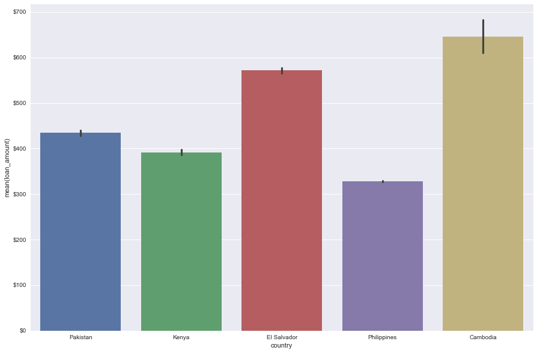

```python
import matplotlib.ticker as mtick
f,ax=plt.subplots(figsize=(15,10))
sns.barplot(data=df,x="country",y="loan_amount")
fmt = '${x:,.0f}'
tick = mtick.StrMethodFormatter(fmt)
ax.yaxis.set_major_formatter(tick)
plt.show()
```

# Step_five: Learn More By Using hue In Your Visualization

*visualize even more data on one bar plot by visualizing the loan amount by country, and "nesting" by gender*

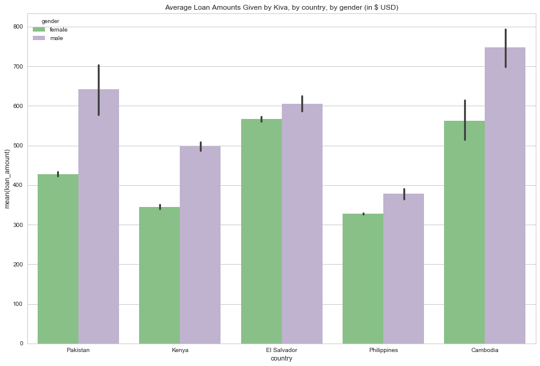

```python
plt.figure(figsize=(15,10))
sns.set_style("whitegrid")
sns.set_palette("Accent")
plt.title("Average Loan Amounts Given by Kiva, by country, by gender (in $ USD)")
sns.barplot(data=df,x="country",y="loan_amount",hue="gender")
plt.show()
```

# step_sex::answer some Questions

*Question_one::On average, do female or male recipients receive larger loans from Kiva?*

answer:: male receive larger loans from kiva

*Question_two::Which country has the least disparity in loan amounts awarded by gender?*

answer::EL Salvador

*Question_three::Based on the data, what kind of recommendations can you make to Kiva about the loans they give?*

answer:: Kiva should work to decrease the gender loan gap.

*Question_four::What actions could be taken to implement the recommendations you've made?*

answer::Some actions could be:

Kiva could hold workshops focused on women-led projects (to see more women-led project)

Kiva could require that an equal amount of loans be given to male and female-driven projects

# Step_seven: Box Plots With Kiva Data

*make a box plot to compare the distribution of loans by country.*

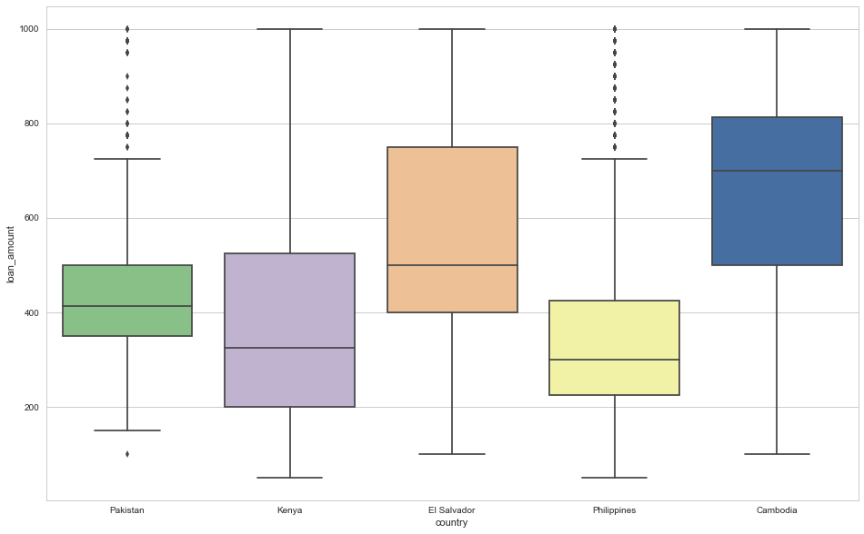

```python
plt.figure(figsize=(16,10))
sns.boxplot(data=df,x="country",y="loan_amount")
plt.show()
```

# step_eight::answer some Questions

*Question_two:In which country would you be most likely to receive the largest loan amount?*

answer::Cambodia

# step_nine:: Box Plot by Activity

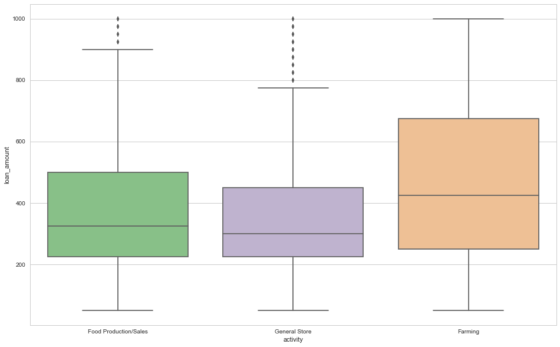

```python
plt.figure(figsize=(16,10))
sns.boxplot(data=df,x="activity",y="loan_amount")
plt.show()
```

# step_ten::answer some Questions

*Question_one::What does this visualization reveal that previous ones did not?*

answer::It shows you the loan amounts by activity, rather than country.

On average, "Farming" receives the largest loan amount and also has the widest distribution

# step_eleven::Violin Plots

*Create a violin plot that visualizes the distribution of loan amount by country*

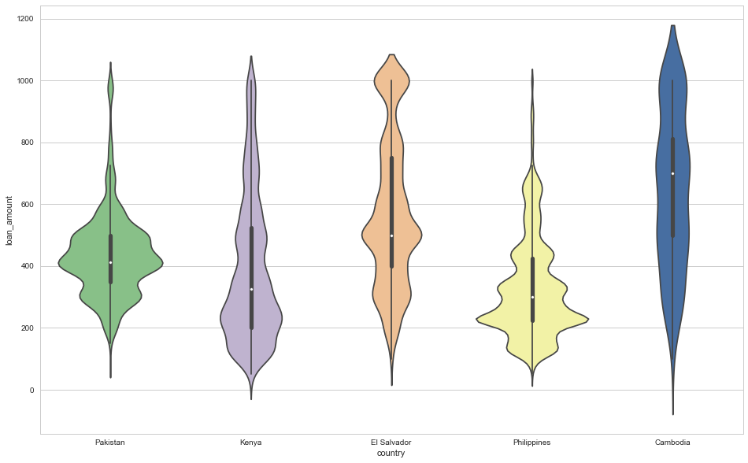

```python
plt.figure(figsize=(16,10))
sns.violinplot(data=df,x="country",y="loan_amount")
plt.show()
```

# Step_twelve: Split Violin Plots by gender

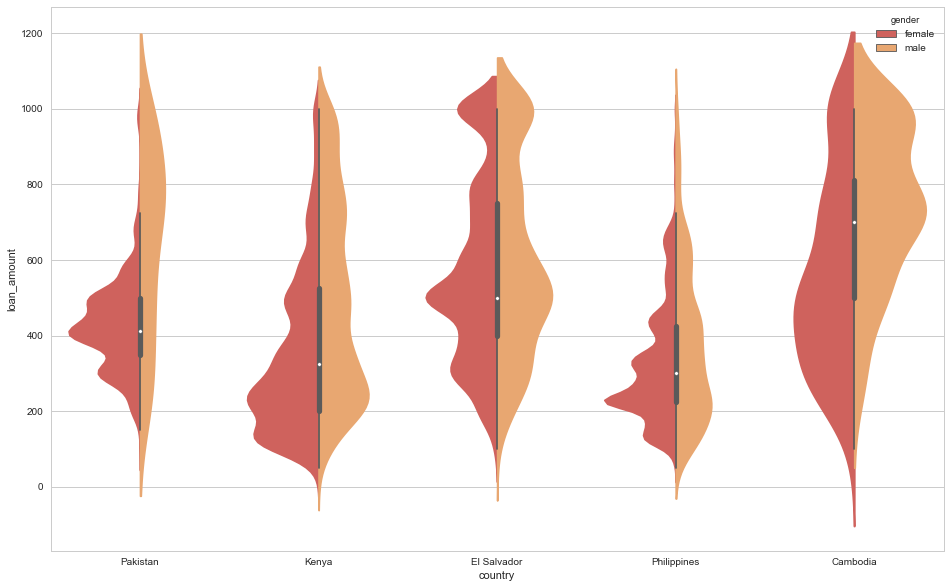

```python
plt.figure(figsize=(16,10))
sns.set_palette("Spectral")
sns.violinplot(data=df,x="country",y="loan_amount",hue="gender",split=True)
plt.show()
```

# step_thirteen::answer some Questions

*Question_one::What does this visualization reveal about the distribution of loan amounts within countries by gender?*

answer::In Pakistan, the average loan amount received by women is much less than the average loan amount received by men. The same can be said for Cambodia (more or less). In El Salvador, there is a fairly equal distribution of loans (total number of loans) between genders, as well as similar median loan amounts (on average).